# Main Analysis

Mara Rehmer

20 8 2021

## Loading and inspecting the data

First of all we load the data set and take a look at it.

```
## Rows: 6,780
## Columns: 27
## $ submission_id <dbl> 2594, 2594, 2594, 2594, 2594, 2594, 2594, 2594, 2594, 25~
## $ QUD           <lgl> NA, NA, NA, NA, NA, NA, NA, NA, NA, NA, NA, NA, NA, NA, ~
## $ RT            <dbl> 2660, 1937, 1820, 1893, 1844, 1941, 1855, 1871, 1643, 17~
## $ a             <chr> NA, NA, "links/left", "links/left", NA, "links/left", "l~
## $ age           <dbl> 24, 24, 24, 24, 24, 24, 24, 24, 24, 24, 24, 24, 24, 24, ~
## $ comments      <chr> "Erkennung von zufälligen Mustern", "Erkennung von zufäl~
## $ correctness   <chr> "correct", "correct", "correct", "correct", "incorrect",~
## $ d             <chr> NA, NA, "rechts/right", "rechts/right", NA, "rechts/righ~
## $ education     <chr> "Graduated High School", "Graduated High School", "Gradu~
## $ endTime       <dbl> 1.629098e+12, 1.629098e+12, 1.629098e+12, 1.629098e+12, ~
## $ expected      <chr> "oben/up", "unten/down", "rechts/right", "rechts/right",~
## $ experiment_id <dbl> 276, 276, 276, 276, 276, 276, 276, 276, 276, 276, 276, 2~
## $ gender        <chr> "female", "female", "female", "female", "female", "femal~
## $ key1          <chr> "w", "w", "a", "a", "w", "a", "a", "w", "a", "a", "a", "~
## $ key2          <chr> "s", "s", "d", "d", "s", "d", "d", "s", "d", "d", "d", "~
## $ key_pressed   <chr> "w", "s", "d", "d", "w", "d", "d", "s", "a", "d", "d", "~
## $ languages     <chr> "german", "german", "german", "german", "german", "germa~
## $ picture       <chr> "data:…
## $ question      <chr> "Welche Matrix wurde zufällig erzeugt? / Which matrix is~
## $ s             <chr> "unten/down", "unten/down", NA, NA, "unten/down", NA, NA~
## $ startDate     <chr> "Mon Aug 16 2021 08:57:25 GMT+0200 (Mitteleuropäische So~
## $ startTime     <dbl> 1.629097e+12, 1.629097e+12, 1.629097e+12, 1.629097e+12, ~
## $ switch_rate   <dbl> 7.00, 6.00, 2.00, 3.00, 5.00, 8.00, 4.00, 0.00, 1.00, 9.~
## $ timeSpent     <dbl> 11.95198, 11.95198, 11.95198, 11.95198, 11.95198, 11.951~
## $ trial_name    <chr> "identification_practice", "identification_practice", "i~
## $ trial_number  <dbl> 1, 2, 3, 4, 5, 6, 7, 8, 9, 10, 1, 2, 3, 4, 5, 6, 7, 8, 9~
## $ w             <chr> "oben/up", "oben/up", NA, NA, "oben/up", NA, NA, "oben/u~
```

### Participants

A total of 19 participants took part in an online version of a Perception of Randomness task. There were 5 male, 12 female and 2 participants who chose not to answer, with ages ranging from 20 to 64. There were 10 participants in the discrimination condition and 9 in the identification condition. The first 4 participants contributed 510 data points (10 for each switch rate), the subsequent participants contributed 6 data points for each switch rate plus 10 practice trials.

### General properties and cleaning

First we have a look at the comments which were answers to our question whether the participant had any idea what this experiment is about.

```
## [1] "Erkennung von zufälligen Mustern"
## [2] "- Does priming with (more) obvious h (or  v) split matrices influence whether non-split matrices are labeled with h (or v)?\n\n- Reaction time of button press for ambiguously split matrices, and the effect of surrounding stimuli on decision time"
## [3] "Clueless"
## [4] NA
## [5] "Maybe some kind of machine learning, that needs multiple test cases to more accuratly predict human behaviour."
## [6] "perception and identification"
## [7] "No idea :)"
## [8] "no"
## [9] "Wie lange sind die Augen konzentriert genut und in der Lage, eine Symetrie zu erkennen? Wie eindeutig muss die Struktur des Bildes von einander abweichen, um die horizontale oder vertikale Veränderung der Struktur zu erkennen?"
```

Answer 1 goes in the right direction.

We check general properties of the data, like a summary of the reaction time (`RT`) and the overall time spent on the experiment (`timeSpent`).

```
## [1] "Summary of RT"
```

```
##    Min. 1st Qu.  Median    Mean 3rd Qu.    Max.
##    1508    1822    1960    2506    2282  934470
```

```
## [1] "Summary of time spent"
```

```
##    Min. 1st Qu.  Median    Mean 3rd Qu.    Max.
##   10.72   14.42   17.89   19.44   25.62   35.07
```

The maximal RT is very high, there is also a big span from minimal to maximal time spent.

We will clean the data by only selecting the main trials and the columns that are relevant for us. We will also get rid of outliers. The columns that are relevant for our analysis are:  
`submission_id`: individual identifier of each subject  
`trial_name`: which we rename to `condition` which is either identification or discrimination  
`trial_number`: number of trial (used for plotting the outliers)  
`switch_rate`: ordered factor ranging from 0 to 1 in steps of 0.02 indicating the generating process of the stimuli (named `swr`)  
`correctness`: whether the answer of the participant was correct  
`RT`: reaction time in ms for each trial (base line is 1500 ms from showing the stimulus)  
`timeSpent`: overall time spent

We choose to exclude individual trials with a reaction time (`RT`) bigger than 8000 ms, because we cannot be sure that participants recall the stimulus correctly after this time and just press any of the keys to continue to the next trial. We don’t exclude “too fast” reaction times because answers can only be entered after the stimulus was shown for 1500 ms. We make `swr` (switch rate) an unordered factor and have a look at which data points do not fulfill our time limits and therefore qualify as outliers.

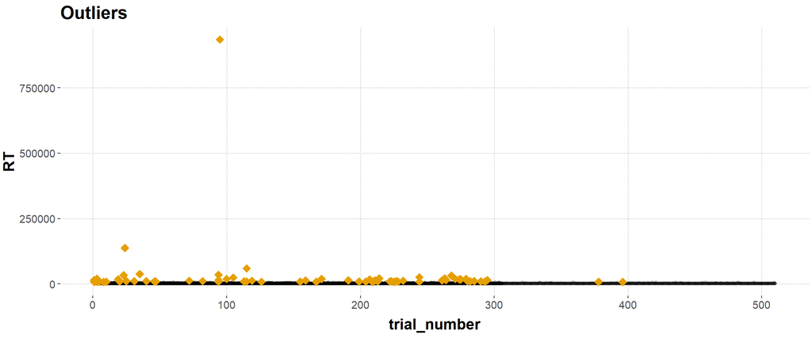

We excluded 73 trials for having too long reaction times.

### Summary statistics

We will have a look at some summary statistics like the mean accuracy for both conditions.

```
## # A tibble: 2 x 2
##   condition      mean_accuracy
##   <chr>                  <dbl>
## 1 discrimination         0.765
## 2 identification         0.507
```

The accuracy for both groups, especially for the identification condition, looks off. In the Pilot part of our experiment, both conditions had a mean accuracy of over 0.8. We will plot each participant’s responses in each switch rate to get an overview of the data.

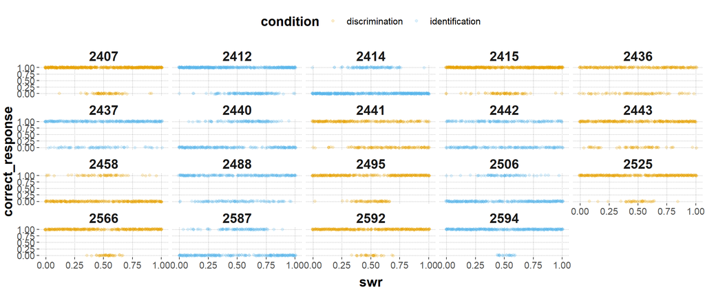

## Hypothesis

The hypothesis of the original paper states:

> The probability of correctly identifying stimuli from R [random source] and N [non-random source] coincides with the ease of distinguishing between the two sources.

Or in other words: The proportion of correct answers for both conditions is not significantly different.

## Analysis

It is a 2x51 mixed factorial design, where the first factor is `condition` with two values *discrimination* or *identification*. The second factor is `switch rate` which has 51 levels (from 0 to 1 in steps of 0.02). Each participant contributes data points for only one condition (between-subjects) but multiple data points (6 or 10) for each switch rate (within-subject, repeated measures).

We use a Bayesian Logistic Regression Model which models the `correctness` as dependent variable in terms of `condition` and `switch_rate` as independent variables. We choose this as a measure of proportion of correct responses in each condition and switch rate instead of a beforehand calculated summary statistic like accuracy which was used in the original paper. We choose not to average over all participants and switch rates in the two condition because this summary of the data will lead our model to underestimate the variance in the data.

```
##  Family: bernoulli
##   Links: mu = logit
## Formula: correctness ~ condition * swr + (1 | submission_id)
##    Data: clean_data %>% mutate(correctness = correctness == (Number of observations: 6557)
## Samples: 4 chains, each with iter = 5000; warmup = 2500; thin = 1;
##          total post-warmup samples = 10000
##
## Group-Level Effects:
## ~submission_id (Number of levels: 19)
##               Estimate Est.Error l-95% CI u-95% CI Rhat Bulk_ESS Tail_ESS
## sd(Intercept)     1.43      0.26     1.02     2.04 1.00     3578     5973
##
## Population-Level Effects:
##                                 Estimate Est.Error l-95% CI u-95% CI Rhat
## Intercept                           1.61      0.47     0.67     2.52 1.00
## conditionidentification            -1.39      0.68    -2.74    -0.05 1.00
## swr0.02                             0.83      0.48    -0.09     1.82 1.00
## swr0.04                             0.69      0.45    -0.16     1.60 1.00
## swr0.06                             1.07      0.50     0.13     2.11 1.00
## swr0.08                             0.23      0.41    -0.54     1.07 1.00
## swr0.1                              0.08      0.40    -0.67     0.88 1.00
## swr0.12                             0.23      0.41    -0.54     1.05 1.00
## swr0.14                             0.20      0.41    -0.58     1.03 1.00
## swr0.16                            -0.08      0.40    -0.84     0.73 1.00
## swr0.18                             0.64      0.45    -0.19     1.58 1.00
## swr0.2                              0.83      0.49    -0.07     1.84 1.00
## swr0.22                             0.68      0.46    -0.18     1.60 1.00
## swr0.24                             0.68      0.45    -0.17     1.61 1.00
## swr0.26                             0.85      0.48    -0.05     1.82 1.00
## swr0.28                             0.86      0.48    -0.03     1.85 1.00
## swr0.3                              0.36      0.42    -0.44     1.22 1.00
## swr0.32                             1.32      0.55     0.32     2.48 1.00
## swr0.34                            -0.39      0.36    -1.09     0.33 1.00
## swr0.36                            -0.28      0.38    -1.01     0.50 1.00
## swr0.38                            -0.65      0.37    -1.35     0.10 1.00
## swr0.4                             -1.53      0.34    -2.18    -0.85 1.00
## swr0.42                            -1.13      0.35    -1.81    -0.44 1.00
## swr0.44                            -1.75      0.33    -2.41    -1.10 1.00
## swr0.46                            -2.23      0.34    -2.91    -1.57 1.00
## swr0.48                            -1.62      0.34    -2.27    -0.95 1.00
```

[output cut: 168 more lines]

```
## conditionidentification:swr0.8      5758     6778
## conditionidentification:swr0.82     5921     6729
## conditionidentification:swr0.84     5627     7481
## conditionidentification:swr0.86     5600     7127
## conditionidentification:swr0.88     6174     7173
## conditionidentification:swr0.9      5841     6572
## conditionidentification:swr0.92     5851     6520
## conditionidentification:swr0.94     5056     6810
## conditionidentification:swr0.96     5975     6884
## conditionidentification:swr0.98     5128     6899
## conditionidentification:swr1        6143     6678
##
## Samples were drawn using sampling(NUTS). For each parameter, Bulk_ESS
## and Tail_ESS are effective sample size measures, and Rhat is the potential
## scale reduction factor on split chains (at convergence, Rhat = 1).
```

The `Intercept`, or base level estimate for switch rate = 0 in the discrimination condition, is 1.61 (corresponding to a proportion of correct answers of approx. 0.83), the 95% Credible Interval (CI) is quite large [0.67, 2.52] but only includes positive numbers. The estimate for `conditionidentification` is -1.39 and the 95% CI ranges from [-2.74, -0.05] which is why we are confident that the proportion of correct answers is less in the identification condition. Only some levels of `swr` and the interaction terms between `conditionidentification:swr` are meaningful right now (because their CI does not include zero). We can see that the estimates for switch rates = 0.4 to switch rate = 0.66 are negative, so the proportion of correct answers goes down. This makes sense because switch rates closer to 0.5 are less easy to tell apart in both conditions from the random half. For switch rates 0.36 to 0.66 the interaction estimates are credibly above zero meaning that there were more mistakes made in the discrimination condition for these switch rates, this coincides with our observation from the data above - we recall that the performance for the identification condition sometimes looked like it was turned upside down.  
We can also see that there is substantial variability across the participants (`submission_id`) with an estimate of 1.43. This is also consistent with our observations because the performance had very high variability.

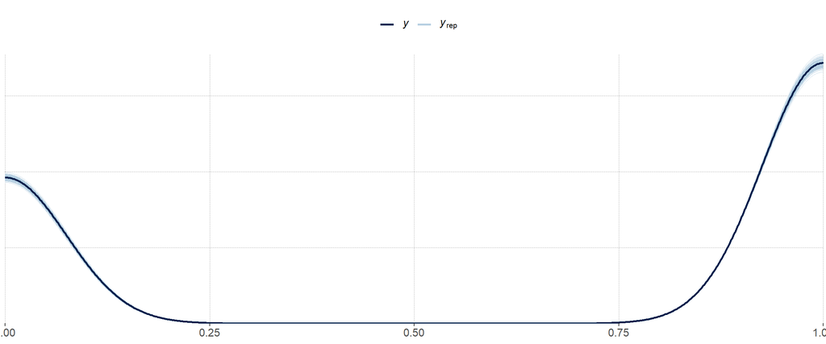

Looking at the `pp_check` we can see that the model quite neatly captures the nature of our data.

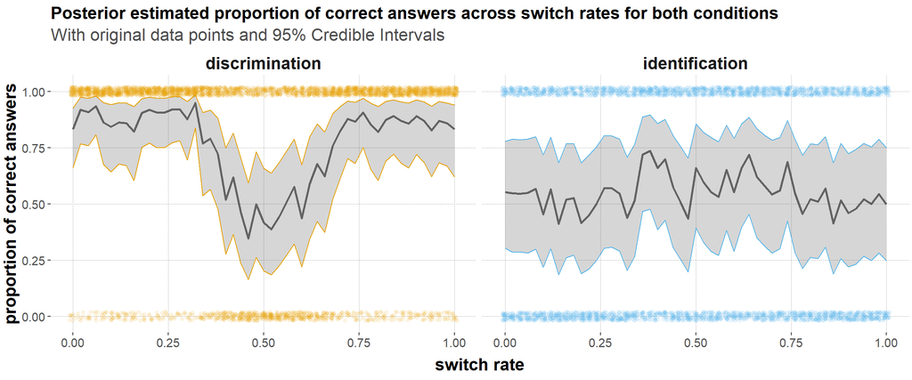

Now looking at the plot of the posterior estimates and their 95% CI, the proportion of correct answers in the discrimination condition looks similar to the one we gained in our pilot study. For lower and higher switch rates (further away from 0.5) the estimated performance is quite high (above 0.75). Then around 0.3 the proportion of correct answers goes down as expected, even below 0.5, and then goes up again until a switch rate of around 0.74 where the performance stabilizes at around 0.85. The plot of the identification condition on the other hand does not at all look like the one from the pilot. Here we see a jagged line that stays around 0.5 which is just chance.

### Conclusion

If the data was representative of such task, we would conclude that there is definitely a difference between the two conditions and say that the probability of correctly identifying stimuli from R and N does NOT coincide with the ease of distinguishing between the two sources. We would conclude that the identification task was a lot harder and people could only identify correctly at chance.  
But since we are not confident in the data that we obtained, we will not draw such conclusions. To investigate the hypothesis, it would be best to repeat this experiment in a controlled environment (like a lab), to be able to answer potential questions the participants might have. It would also help to include not only practice trials, but practice trials with feedback regarding the correctness of the response. This would probably diminish obtaining data produced by misunderstanding the tasks. More elaborate criticism and propositions in the discussions part of our final paper.